# MNIST

## Classification Problems on MNIST

This notebook use [MNIST dataset](https://en.wikipedia.org/wiki/MNIST_database), which is a set of 70,000 small images of digits handwritten by high school students and employees of the US Census Bureau, for Classification

```python
from sklearn.datasets import fetch_openml

mnist = fetch_openml('mnist_784', version=1, as_frame=False) # https://github.com/ageron/handson-ml2/issues/518#issuecomment-1001289203
mnist.keys()
```

```
dict_keys(['data', 'target', 'frame', 'categories', 'feature_names', 'target_names', 'DESCR', 'details', 'url'])
```

Datasets loaded by scikit-learn generally have a similar dictionary structure, including the following:

- A `DESCR` key describing the dataset
- A `data` key containing an array with one row per instance and one column per feature
- A `target` key containing an array with the labels

```python
import math

data, labels = mnist["data"], mnist["target"]
data.shape

print(
    "There are {0} images, and each image has {1} features. ".format(data.shape[0], data.shape[1]) +
    "This is because each image is {0} × {0} pixels, and each feature simply represents one pixel’s intensity, from 0 (white) to 255 (black).".format(int(math.sqrt(data.shape[1])))
)
```

```
There are 70000 images, and each image has 784 features. This is because each image is 28 × 28 pixels, and each feature simply represents one pixel’s intensity, from 0 (white) to 255 (black).
```

Let’s take a peek at one digit from the dataset:

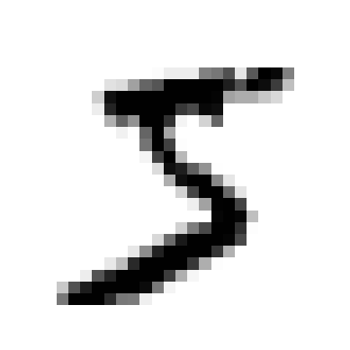

```python
import matplotlib as mpl
import matplotlib.pyplot as plt

example_digit = data[0]
example_image = data[0].reshape(28, 28)

plt.imshow(example_image, cmap="binary")
plt.axis("off")
plt.show()
```

```python
print("This is the number '{0}'".format(labels[0]))
```

```
This is the number '5'
```

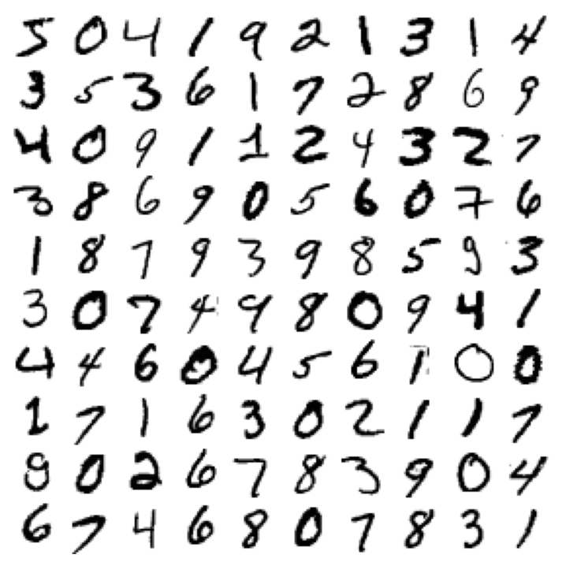

```python
import numpy as np

def plot_digits(instances, images_per_row=10, **options):
    size = 28
    images_per_row = min(len(instances), images_per_row)
    # This is equivalent to n_rows = ceil(len(instances) / images_per_row):
    n_rows = (len(instances) - 1) // images_per_row + 1

    # Append empty images to fill the end of the grid, if needed:
    n_empty = n_rows * images_per_row - len(instances)
    padded_instances = np.concatenate([instances, np.zeros((n_empty, size * size))], axis=0)

    # Reshape the array so it's organized as a grid containing 28×28 images:
    image_grid = padded_instances.reshape((n_rows, images_per_row, size, size))

    # Combine axes 0 and 2 (vertical image grid axis, and vertical image axis),
    # and axes 1 and 3 (horizontal axes). We first need to move the axes that we
    # want to combine next to each other, using transpose(), and only then we
    # can reshape:
    big_image = image_grid.transpose(0, 2, 1, 3).reshape(n_rows * size,
                                                         images_per_row * size)
    # Now that we have a big image, we just need to show it:
    plt.imshow(big_image, cmap = mpl.cm.binary, **options)
    plt.axis("off")

plt.figure(figsize=(9,9))
example_images = data[:100]
plot_digits(example_images, images_per_row=10)
plt.show()
```

Let's convert label from string to number to make the following processing easier and split training and test data test

```python
labels = labels.astype(np.uint8)

NUM_TRAINING_INSTANCES = 60000

training_instances = data[:NUM_TRAINING_INSTANCES]
training_labels = labels[:NUM_TRAINING_INSTANCES]
test_instances = data[NUM_TRAINING_INSTANCES:]
test_labels = labels[NUM_TRAINING_INSTANCES:]
```

## Binary Classifier - Classififying "5"

Let's convert the labels to a boolean type where `True` means "is 5" and `False`, otherwise:

```python
training_labels_5 = (training_labels == 5)
test_labels_5 = (test_labels == 5)

training_labels_5
```

```
array([ True, False, False, ...,  True, False, False], shape=(60000,))
```

### Stochastic Gradient Descent (SGD) Classifier

```python
from sklearn.linear_model import SGDClassifier

sgd_classifier = SGDClassifier(random_state=42)
sgd_classifier.fit(training_instances, training_labels_5)

sgd_classifier.predict([example_digit])
```

```
array([ True])
```

## Performance Measures

### Cross Validation

We use the `cross_val_score()` function to evaluate our `SGDClassifier` model, using K-fold cross-validation with 3 folds. Remember that K-fold cross-validation means splitting the training set into K folds (in this case, 3), then making predictions and evaluating them on each fold using a model trained on the remaining folds

```python
from sklearn.model_selection import cross_val_score

cross_val_score(sgd_classifier, training_instances, training_labels_5, cv=3, scoring="accuracy")
```

```
array([0.95035, 0.96035, 0.9604 ])
```

Occasionally we will need more control over the cross-validation process than what Scikit-Learn provides off the shelf. In these cases, we can implement our own cross-validation. The following code does roughly the same thing as scikit-learn’s `cross_val_score()` function above, and it prints the result in the same ballpark.

We use the `StratifiedKFold` class that performs stratified sampling, i.e. to produce folds that contain a representative ratio of each class. At each iteration the code creates a clone of the classifier, trains that clone on the training folds, and makes predictions on the test fold. Then it counts the number of correct predictions and outputs the ratio of correct predictions.

```python
from sklearn.model_selection import StratifiedKFold
from sklearn.base import clone

skfolds = StratifiedKFold(n_splits=3)

for train_index, test_index in skfolds.split(training_instances, training_labels_5):
    sgd_classifier_clone = clone(sgd_classifier)

    training_instances_folds = training_instances[train_index]
    training_labels_folds = training_labels_5[train_index]

    test_instances_folds = training_instances[test_index]
    test_labels_folds = training_labels_5[test_index]

    sgd_classifier_clone.fit(training_instances_folds, training_labels_folds)
    predictions = sgd_classifier_clone.predict(test_instances_folds)
    n_correct = sum(predictions == test_labels_folds)
    print(n_correct / len(predictions))
```

```
0.95035
```

```
0.96035
```

```
0.9604
```

```python
prob_5 = len([label for label in training_labels_5 if label == True])/len(training_labels_5)

print(
    "This reault, although looks promising, shows little improvements over baseline given that only about " +
    "{0}% of the images are 5's".format(prob_5 * 100)
)
```

```
This reault, although looks promising, shows little improvements over baseline given that only about 9.035% of the images are 5's
```

```python
print(
    "We can have a dummy classifier that always say 'Not a 5' for all training instance that still achive about " +
    "{0}% accuracy".format((1 - prob_5) * 100)
)
```

```
We can have a dummy classifier that always say 'Not a 5' for all training instance that still achive about 90.96499999999999% accuracy
```

This demonstrates why **accuracy is generally not the preferred performance measure for classifiers**, especially when we are dealing with *skewed datasets* (i.e., when some classes are much more frequent than others).

### Confusion Matrix

A much better way to evaluate the performance of a classifier is to look at the **confusion matrix**. The general idea is to count the number of times instances of class A are classified as class B. For example, to know the number of times the classifier confused images of 5s with 3s, we would look in the 5th row and 3rd column of the confusion matrix.

We use the `cross_val_predict()` function for this purpose. Just like the `cross_val_score()` used above, `cross_val_predict()` performs K-fold cross-validation, but instead of returning the evaluation scores, it returns the predictions made on each test fold. This means that we get a clean prediction for each instance in the training set (“clean” meaning that the prediction is made by a model that never saw the data during training).

We assign the clean prediction to a variable named `predictions` which essentially contains the predicted labels for each training instance. Then we use `confusion_matrix()` to get the matrix:

```python
from sklearn.metrics import confusion_matrix
from sklearn.model_selection import cross_val_predict

predicitons = cross_val_predict(sgd_classifier, training_instances, training_labels_5, cv=3)
confusion_matrix(training_labels_5, predicitons)
```

```
array([[53892,   687],
       [ 1891,  3530]])
```

Each **row** in a confusion matrix represents an **labeled** class, while each *column* represents a *predicted* class.

A perfect classifier would have only true positives and true negatives, so **its confusion matrix would have nonzero values only on its main diagonal**

### Accuracy of Positive (FP & TP) Predictions

The **precision** of a classifier is defined as **the number of correctly identified positives among all *predicted* positives**:

$precision = \frac{TP}{TP + FP}$

Precision is helpful but can sometimes leads to a pretty dramatic misconception. For example, we would have a perfect precision if we simply make one true positive and stay there forever. In that case, we have a precision of

$precision = \frac{1}{1 + 0} = 1$

Therefore, precision is used along with another metric - **recall**: **the number of correctly identified positives among all *actual* positives**:

$recall = \frac{TP}{TP + FN}$

scikit-learn provides several functions to compute both of them:

```python
from sklearn.metrics import precision_score, recall_score

precision = precision_score(training_labels_5, predicitons)
recall = recall_score(training_labels_5, predicitons)
```

```python
print(
    "This means when the classifier claims an image represents a 5, " +
    "it is correct only {0}% of the time. Moreover, it only detects {1}% of the 5's.".format(
        '%.1f'%(precision * 100),
        '%.1f'%(recall * 100)
    )
)
```

```
This means when the classifier claims an image represents a 5, it is correct only 83.7% of the time. Moreover, it only detects 65.1% of the 5's.
```

It is often convenient to combine precision and recall into a single metric called the **$F_1$ score**, which is a simple way to compare two classifiers.

$F_1 = 2 \times \frac{precision \times recall}{precision + recall} = \frac{TP}{TP + \frac{FN + FP}{2}}$

The F1 score is the harmonic mean of precision and recall. Whereas the regular mean treats all values equally, the harmonic mean gives much more weight to low values. As a result, *a classifier will only get a high F1 score if both recall and precision are high*.

```python
from sklearn.metrics import f1_score

f1_score(training_labels_5, predicitons)
```

```
0.7325171197343847
```

Note that $F_1$ score is not a measure of the "absolute" quality of a classifier. It favors classifiers that have similar precision and recall. This is not always the case we want for some problems. For example,

- if we train a classifier to detect videos that are safe for kids, we would need low recall (reject many good videos) and high precision (keep only safe ones) - **I want all bad video out even at the cost of good being thrown away**
- suppose we train a classifier to detect shoplifters in surveillance images: it is fine with 30% precision as long as it has 99% recall - **I want all shoplifters identified at the cost of pick up couple of innocents**

We cannot have both high precision and recall at the same time. **Increasing precision reduces recall, and vice versa**. This is called the **precision/recall trade-off**.

### Precision/Recall Trade-off

If we imagine a x-axis and align all digits on it, the more a digit looks like a 5 the further it's place on the right side of the axis; similary those that are not 5 are placed on the left. So the value on the x-axis represents the similarity to 5.

The `SGDClassifier` makes its classification based on a score calculated by a decision function. If that score is greater than a threshold, it assigns the instance to the positive class; otherwise it assigns it to the negative class. Figure below shows a few digits positioned from the lowest score on the left to the highest score on the right. Suppose the decision threshold is positioned at the central arrow (between the two 5s): we see 4 true positives (actual 5s) on the right of that threshold, and 1 false positive (actually a 6). Therefore, with that threshold, the precision is 80% (4 out of 5). But out of 6 actual 5s, the classifier only detects 4, so the recall is 67% (4 out of 6). If we raise the threshold (move it to the arrow on the right), the false positive (the 6) becomes a true negative, thereby increasing the precision (up to 100% in this case), but one true positive becomes a false negative, decreasing recall down to 50%. Conversely, lowering the threshold increases recall and reduces precision.

[figure not shown]

scikit-learn does not let us set the threshold directly, but it does give access to the decision scores that it uses to make predictions. Instead of calling the classifier’s `predict()` method, we can call its `decision_function()` method, which returns a score for each instance, and then use any threshold we want to make predictions based on those scores:

```python
example_score = sgd_classifier.decision_function([example_digit])
example_score
```

```
array([2164.22030239])
```

[The `SGDClassifier` uses a threshold of 0](https://scikit-learn.qubitpi.org/modules/classification_threshold.html). If we raise the threshold to 8000, the `example_score` would give `example_digit` a "non-5" prediction

How do we decide which threshold to use if different models needs various Precision/Recall Trade-off for different problems? We do that in 3 steps

1. Use `cross_val_predict()` function to get the scores of all instances in the training set, but this time specify that we want to return decision scores instead of predictions`
2. Use the `precision_recall_curve()` function to compute precision and recall for all possible thresholds
3. Plot precision and recall as functions of the threshold

The 3 steps are coded up below:

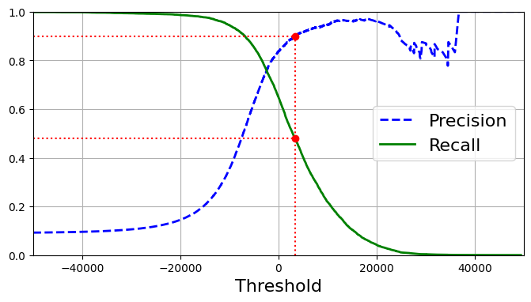

```python
from sklearn.metrics import precision_recall_curve

scores = cross_val_predict(sgd_classifier, training_instances, training_labels_5, cv=3, method="decision_function")

precisions, recalls, thresholds = precision_recall_curve(training_labels_5, scores)

recall_90_precision = recalls[np.argmax(precisions >= 0.90)]
threshold_90_precision = thresholds[np.argmax(precisions >= 0.90)]

plt.figure(figsize=(8, 4))
plt.plot(thresholds, precisions[:-1], "b--", label="Precision", linewidth=2)
plt.plot(thresholds, recalls[:-1], "g-", label="Recall", linewidth=2)
plt.legend(loc="center right", fontsize=16)
plt.xlabel("Threshold", fontsize=16)
plt.grid(True)
plt.axis([-50000, 50000, 0, 1])
plt.plot([threshold_90_precision, threshold_90_precision], [0., 0.9], "r:")
plt.plot([-50000, threshold_90_precision], [0.9, 0.9], "r:")
plt.plot([-50000, threshold_90_precision], [recall_90_precision, recall_90_precision], "r:")
plt.plot([threshold_90_precision], [0.9], "ro")
plt.plot([threshold_90_precision], [recall_90_precision], "ro")
plt.show()
```

Another way to select a good precision/recall trade-off is to plot precision directly against recall

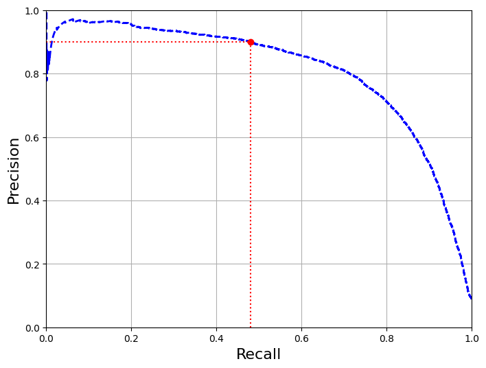

```python
plt.figure(figsize=(8, 6))
plt.plot(recalls, precisions, "b--", label="Precision", linewidth=2)
plt.xlabel("Recall", fontsize=16)
plt.ylabel("Precision", fontsize=16)
plt.axis([0, 1, 0, 1])
plt.grid(True)
plt.plot([recall_90_precision, recall_90_precision], [0., 0.9], "r:")
plt.plot([0.0, recall_90_precision], [0.9, 0.9], "r:")
plt.plot([recall_90_precision], [0.9], "ro")
plt.show()
```

We can see that precision really starts to fall sharply around 80% recall. We will probably want to select a precision/recall trade-off just before that drop.

```python
threshold_90_precision = thresholds[np.argmax(precisions >= 0.90)]
predictions_90 = (scores >= threshold_90_precision)
precision_score(training_labels_5, predictions_90)
```

```
0.9000345901072293
```

### The ROC Curve

The receiver operating characteristic (ROC) curve is another performance measure used with *binary classifiers*. It is very similar to the precision/recall curve, but instead of plotting precision versus recall,

$\text{ROC curve} = \frac{\text{recall}}{\text{false positive rate}}$

where

$\text{false positive rate} = 1 - (\text{the ratio of negative instances correctly classified as negative}) = \text{ratio of negative instances incorrectly classified as positive}$

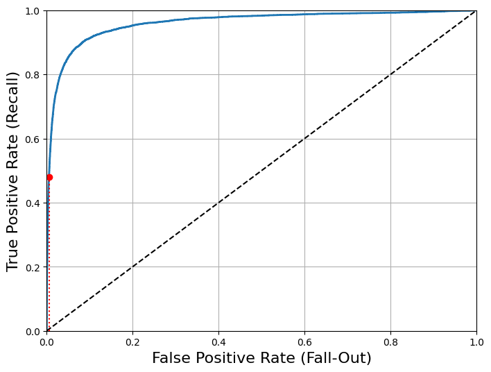

```python
from sklearn.metrics import roc_curve

fpr, tpr, thresholds = roc_curve(training_labels_5, scores)

plt.figure(figsize=(8, 6))
plt.plot(fpr, tpr, linewidth=2, label=None)
plt.plot([0, 1], [0, 1], 'k--')
plt.axis([0, 1, 0, 1])
plt.xlabel('False Positive Rate (Fall-Out)', fontsize=16)
plt.ylabel('True Positive Rate (Recall)', fontsize=16)
plt.grid(True)
fpr_90 = fpr[np.argmax(tpr >= recall_90_precision)]
plt.plot([fpr_90, fpr_90], [0., recall_90_precision], "r:")
plt.plot([0.0, fpr_90], [recall_90_precision, recall_90_precision], "r:")
plt.plot([fpr_90], [recall_90_precision], "ro")
plt.show()
```

The dotted line represents the ROC curve of a purely random classifier; **a good classifier stays as far away from that line as possible (toward the top-left corner)**.

One way to compare classifiers is to measure the **area under the curve** (**AUC**). A perfect classifier will have a ROC AUC equal to 1, whereas a purely random classifier will have a ROC AUC equal to 0.5

```python
from sklearn.metrics import roc_auc_score

roc_auc_score(training_labels_5, scores)
```

```
0.9604938554008616
```

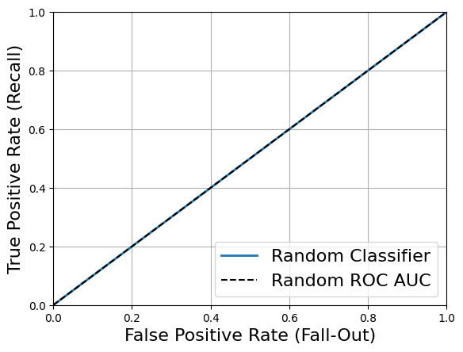

```python
from sklearn.dummy import DummyClassifier
random_classifier = DummyClassifier(strategy="prior")
predict_proba = cross_val_predict(random_classifier, training_instances, training_labels_5, cv=3, method="predict_proba")
scores = predict_proba[:, 1]

fprr, tprr, thresholdsr = roc_curve(training_labels_5, scores)
plt.plot(fprr, tprr, linewidth=2, label="Random Classifier")
plt.plot([0, 1], [0, 1], 'k--', label="Random ROC AUC")
plt.axis([0, 1, 0, 1])
plt.xlabel('False Positive Rate (Fall-Out)', fontsize=16)
plt.ylabel('True Positive Rate (Recall)', fontsize=16)
plt.grid(True)
plt.legend(loc="lower right", fontsize=16)
```

As a rule of thumb, [we should prefer the PR curve whenever the positive class is rare or when we care more about the false positives than the false negatives. Otherwise, use the ROC curve](https://datascience.stackexchange.com/a/106487).

Let’s now train a `RandomForestClassifier` and compare its ROC curve and ROC AUC score to those of the `SGDClassifier`. We need to get scores for each instance in the training set. But due to the way it works, the `RandomForestClassifier` class does not have a `decision_function()` method. Instead, it has a `predict_proba()` method, which returns an array containing a row per instance and a column per class, each containing the probability that the given instance belongs to the given class (e.g., 70% chance that the image represents a 5)

The `roc_curve()` function expects labels and scores, but instead of scores we can give it class probabilities. Let’s use the positive class’s probability as the score:

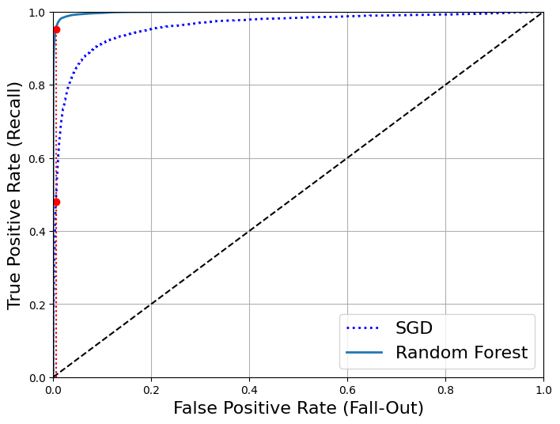

```python
from sklearn.ensemble import RandomForestClassifier

forest_classifier = RandomForestClassifier(random_state=42)
probability_forest = cross_val_predict(forest_classifier, training_instances, training_labels_5, cv=3, method="predict_proba")

scores_forest = probability_forest[:, 1]
fpr_forest, tpr_forest, thresholds_forest = roc_curve(training_labels_5, scores_forest)

recall_for_forest = tpr_forest[np.argmax(fpr_forest >= fpr_90)]

plt.figure(figsize=(8, 6))
plt.plot(fpr, tpr, "b:", linewidth=2, label="SGD")
plt.plot(fpr_forest, tpr_forest, linewidth=2, label="Random Forest")
plt.plot([0, 1], [0, 1], 'k--')
plt.axis([0, 1, 0, 1])
plt.xlabel('False Positive Rate (Fall-Out)', fontsize=16)
plt.ylabel('True Positive Rate (Recall)', fontsize=16)
plt.grid(True)
plt.plot([fpr_90, fpr_90], [0., recall_90_precision], "r:")
plt.plot([0.0, fpr_90], [recall_90_precision, recall_90_precision], "r:")
plt.plot([fpr_90], [recall_90_precision], "ro")
plt.plot([fpr_90, fpr_90], [0., recall_for_forest], "r:")
plt.plot([fpr_90], [recall_for_forest], "ro")
plt.grid(True)
plt.legend(loc="lower right", fontsize=16)

plt.show()
```

```python
roc_auc_score(training_labels_5, scores_forest)
```

```
0.9983436731328145
```

As we see, the `RandomForestClassifier`'s ROC curve looks much better than the `SGDClassifier`’s: it comes much closer to the top-left corner. As a result, its ROC AUC score is also significantly better

## Multiclass Classification

One way to create a system that can classify the digit images into 10 classes (from 0 to 9) is to train 10 binary classifiers, one for each digit (a 0-detector, a 1-detector, a 2- detector, and so on). Then when we want to classify an image, we get the decision score from each classifier for that image and we select the class whose classifier outputs the highest score. This is called the **one-versus-the-rest** (OvR) strategy

Another strategy is to train a binary classifier for every pair of digits: one to distinguish 0s and 1s, another to distinguish 0s and 2s, another for 1s and 2s, and so on. This is called the **one-versus-one** (OvO) strategy. If there are N classes, we need to train N × (N – 1) / 2 classifiers. The main advantage of OvO is that each classifier only needs to be trained on the part of the training set for the two classes that it must distinguish.

Some algorithms (such as Support Vector Machine classifiers) scale poorly with the size of the training set. For these algorithms OvO is preferred because it is faster to train many classifiers on small training sets than to train few classifiers on large training sets. For most binary classification algorithms, however, OvR is preferred.

scikit-learn detects when we try to use a binary classification algorithm for a multiclass classification task, and it automatically runs OvR or OvO, depending on the algorithm. Let’s try this with a Support Vector Machine classifier, using the `sklearn.svm.SVC` class:

```python
from sklearn.svm import SVC

svm_classifier = SVC()
svm_classifier.fit(training_instances, training_labels)
svm_classifier.predict([example_digit])
```

```
array([5], dtype=uint8)
```

The `decision_function()` method returns 10 scores per instance, where the score for 5 is the highest (index starts with 0)

```python
example_digit_scores = svm_classifier.decision_function([example_digit])
example_digit_scores
```

```
array([[ 1.72501977,  2.72809088,  7.2510018 ,  8.3076379 , -0.31087254,
         9.3132482 ,  1.70975103,  2.76765202,  6.23049537,  4.84771048]])
```

But if we want to force scikit-learn to use one-versus-one or one-versus-the-rest, we can use the `OneVsOneClassifier` or `OneVsRestClassifier` classes

```python
from sklearn.multiclass import OneVsRestClassifier

ovr_classifier = OneVsRestClassifier(SVC())
ovr_classifier.fit(training_instances, training_labels)
ovr_classifier.predict([example_digit])
```

```
array([5], dtype=uint8)
```

Training an `SGDClassifier` (or a `RandomForestClassifier`) is just as easy:

```python
sgd_classifier.fit(training_instances, training_labels)
sgd_classifier.predict([example_digit])
```

```
array([3], dtype=uint8)
```

```python
sgd_classifier.decision_function([example_digit])
```

```
array([[-31893.03095419, -34419.69069632,  -9530.63950739,
          1823.73154031, -22320.14822878,  -1385.80478895,
        -26188.91070951, -16147.51323997,  -4604.35491274,
        -12050.767298  ]])
```

```python
cross_val_score(sgd_classifier, training_instances, training_labels, cv=3, scoring="accuracy")
```

```
array([0.87365, 0.85835, 0.8689 ])
```

We can do better simply by scaling the inputs:

```python
from sklearn.preprocessing import StandardScaler

scaler = StandardScaler()
training_instances_scaled = scaler.fit_transform(training_instances.astype(np.float64))
cross_val_score(sgd_classifier, training_instances_scaled, training_labels, cv=3, scoring="accuracy")
```

```
array([0.8983, 0.891 , 0.9018])
```

## Error Analysis

```python
predictions = cross_val_predict(sgd_classifier, training_instances_scaled, training_labels, cv=3)
confusion_matrix = confusion_matrix(training_labels, predictions)
confusion_matrix
```

```
array([[5577,    0,   22,    5,    8,   43,   36,    6,  225,    1],
       [   0, 6400,   37,   24,    4,   44,    4,    7,  212,   10],
       [  27,   27, 5220,   92,   73,   27,   67,   36,  378,   11],
       [  22,   17,  117, 5227,    2,  203,   27,   40,  403,   73],
       [  12,   14,   41,    9, 5182,   12,   34,   27,  347,  164],
       [  27,   15,   30,  168,   53, 4444,   75,   14,  535,   60],
       [  30,   15,   42,    3,   44,   97, 5552,    3,  131,    1],
       [  21,   10,   51,   30,   49,   12,    3, 5684,  195,  210],
       [  17,   63,   48,   86,    3,  126,   25,   10, 5429,   44],
       [  25,   18,   30,   64,  118,   36,    1,  179,  371, 5107]])
```

It’s often more convenient to look at an image representation of the confusion matrix

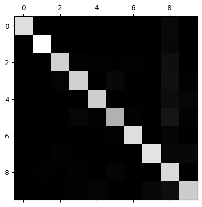

```python
plt.matshow(confusion_matrix, cmap=plt.cm.gray)
plt.show()
```

This confusion matrix looks pretty good, since most images are on the main diago‐ nal, which means that they were classified correctly. The 5s look slightly darker than the other digits, which could mean that there are fewer images of 5s in the dataset or that the classifier does not perform as well on 5s as on other digits

Let’s focus the plot on the errors. We divide each value in the confusion matrix by the number of images in the corresponding class so that we can compare error rates instead of absolute numbers of errors. Then we fill the diagonal with all zeros to keep only the errors and plot the result:

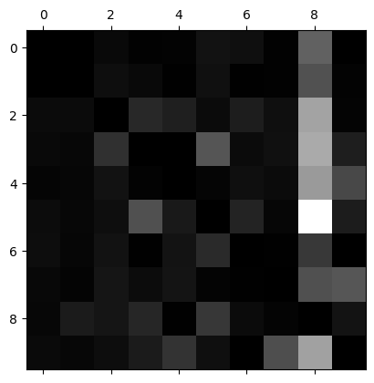

```python
row_sums = confusion_matrix.sum(axis=1, keepdims=True)
normed_confusion_matrix = confusion_matrix / row_sums

np.fill_diagonal(normed_confusion_matrix, 0)
plt.matshow(normed_confusion_matrix, cmap=plt.cm.gray)
plt.show()
```

We can clearly see the kinds of errors the classifier makes. Remember that rows represent actual classes, while columns represent predicted classes. The column for class 8 is quite bright, which tells us that many images get misclassified as 8s. However, the row for class 8 is not that bad, telling us that actual 8s in general get properly classified as 8s

**Analyzing the confusion matrix often gives us insights into ways to improve our classifier**. In our example, it seems that our efforts should be spent on reducing the false 8s by for example

- gathering more training data for digit 8
- engineering new feature for classifier
- pre-processing images

Analyzing individual errors can also be a good way to gain insights on what our classifier is doing and why it is failing

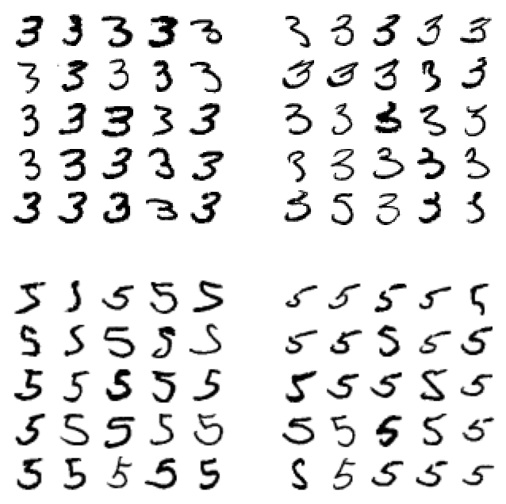

```python
cl_a, cl_b = 3, 5

X_aa = training_instances[(training_labels == cl_a) & (predictions == cl_a)]
X_ab = training_instances[(training_labels == cl_a) & (predictions == cl_b)]
X_ba = training_instances[(training_labels == cl_b) & (predictions == cl_a)]
X_bb = training_instances[(training_labels == cl_b) & (predictions == cl_b)]

plt.figure(figsize=(8,8))
plt.subplot(221); plot_digits(X_aa[:25], images_per_row=5)
plt.subplot(222); plot_digits(X_ab[:25], images_per_row=5)
plt.subplot(223); plot_digits(X_ba[:25], images_per_row=5)
plt.subplot(224); plot_digits(X_bb[:25], images_per_row=5)
plt.show()
```

- The two 5 × 5 blocks on the left show digits classified as 3s
- The two 5 × 5 blocks on the right show images classified as 5s

Some of the digits that the classifier gets wrong (i.e., in the bottom-left and top-right blocks) are so badly written that even a human would have trouble classifying them. However, most misclassified images seem like obvious errors to us, and it’s hard to understand why the classifier made the mistakes it did (But remember that our brain is a fantastic pattern recognition system, and our visual system does a lot of complex preprocessing before any information reaches our consciousness, so the fact that it feels simple does not mean that it is). The reason is that we used a simple `SGDClassifier`, which is a linear model. All it does is assign a weight per class to each pixel, and when it sees a new image it just sums up the weighted pixel intensities to get a score for each class. So since 3s and 5s differ only by a few pixels, this model will easily confuse them

**Using error analysis to improve our model, therefore, requires deep understanding of the math behind the model**

The main difference between 3s and 5s is the position of the small line that joins the top line to the bottom arc. If we draw a 3 with the junction slightly shifted to the left, the classifier might classify it as a 5, and vice versa. In other words, this classifier is quite sensitive to image shifting and rotation. So one way to reduce the 3/5 confusion would be to preprocess the images to ensure that they are well centered and not too rotated. This will probably help reduce other errors as well.

## Multilabel Classification

Let's create a classifier targeting 2 labels:

1. whether or not a number is among 7, 8, or 9
2. whether or not a number is odd

```python
from sklearn.neighbors import KNeighborsClassifier

large_number_training_labels = (training_labels >= 7)
odd_number_training_labels = (training_labels % 2 == 1)
multilabel = np.c_[large_number_training_labels, odd_number_training_labels]

knn_classifier = KNeighborsClassifier()
knn_classifier.fit(training_instances, multilabel)

knn_classifier.predict([example_digit])
```

```
array([[False,  True]])
```

There are many ways to evaluate a multilabel classifier, and selecting the right metric really depends on our project. One approach is to measure the $F_1$ score for each individual label (or any other binary classifier metric discussed earlier), then simply compute the *average*:

```python
predictions = cross_val_predict(knn_classifier, training_instances, multilabel, cv=3)
f1_score(multilabel, predictions, average="macro")
```

```
0.9764102655606048
```

This assumes that all labels are equally important. We may want to give more weight to the classifier’s score on, for example, parity. One simple option is to give each label a weight equal to its **support** (i.e., the number of instances with that target label). To do this, simply set `average="weighted"` in the preceding code.

## Multioutput Classification

Multioutput classification is simply a generalization of multilabel classification where each label can be multiclass

To illustrate this, let’s build a system that removes noise from images. It will take as input a noisy digit image, and it will (hopefully) output a clean digit image, represented as an array of pixel intensities, just like the MNIST images. Notice that the classifier’s output is multilabel (one label per pixel) and each label can have multiple values (pixel intensity ranges from 0 to 255). It is thus an example of a multioutput classification system.

```python
num_features = data.shape[1]

noise = np.random.randint(0, 100, (len(training_instances), num_features))
noised_training_instances = training_instances + noise

noise = np.random.randint(0, 100, (len(test_instances), num_features))
noised_test_instances = test_instances + noise


training_labels_noise = training_instances
test_labels_noise = test_instances
```

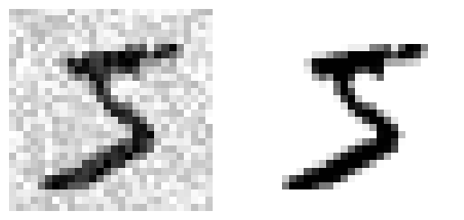

```python
idx = 0

def plot_digit(data):
    image = data.reshape(28, 28)
    plt.imshow(image, cmap = mpl.cm.binary,
               interpolation="nearest")
    plt.axis("off")

plt.subplot(121); plot_digit(noised_training_instances[idx])
plt.subplot(122); plot_digit(training_labels_noise[idx])
plt.show()
```

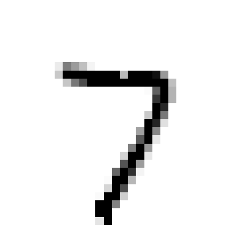

```python
knn_classifier.fit(noised_training_instances, training_labels_noise)
clean_digit = knn_classifier.predict([noised_test_instances[idx]])
plot_digit(clean_digit)
```